# Project: Investigate a Dataset (Replace this with something more specific!)

# Exploratory Data Analysis

## Research Question 1: Genre vs. Vote Average

a. Is a certain type of genres associated with higher rating? Which genre of each subgroup (single-genre and cross-genre) associated with the highest rating?

b. Which year do the movies get the highest rating on average? Do the numbers differ by movies with cross-genre and single genre?

### To Q1a: Is a certain type of genres associated with a higher rating? Which genre of each subgroup single-genre and cross-genre associated with the highest rating?

First of all, I divide the movies into high-level and low-level. To set the level I use the median of average vote. As the visualization, I use a bar chart to print the number of movies for Top 10 high-level genres. In the second part, I focus on the ratings of the subgroup single and cross-genre movies and print the Top 10 best rated genre for each subgroup.

```python
median_voteaverage = df.median().vote_average # get the median amount of vote average - we use the genre_mixtype file
```

```python
median_voteaverage
```

```
6.0
```

```python
# select samples with average vote less than the median as low level
low_level = df[df['vote_average']< 6.0]

# select samples with  average vote greater than or equal to the median as high level
high_level = df[df['vote_average'] >= 6.0]

# ensure these queries included each sample exactly once
num_samples = df.shape[0]
num_samples == low_level['budget'].count() + high_level['budget'].count() # should be True
```

```
True
```

```python
high_level['genres'].value_counts()
```

```
Drama                                           283
Documentary                                     232
Comedy                                          156
Drama|Romance                                    88
Comedy|Drama                                     69
Comedy|Drama|Romance                             53
Comedy|Romance                                   50
Drama|Thriller                                   35
Animation|Family                                 33
Drama|Comedy                                     33
Documentary|Music                                27
Crime|Drama|Thriller                             25
Horror|Thriller                                  23
Drama|Comedy|Romance                             21
Drama|History                                    20
Drama|Music                                      18
Animation|Comedy|Family                          17
Action|Thriller                                  17
Crime|Drama                                      16
Thriller                                         16
Romance|Drama                                    16
Horror                                           14
Music|Documentary                                14
Romance|Comedy                                   14
Animation                                        14
Action|Comedy                                    13
Music                                            13
Drama|History|War                                12
Animation|Comedy                                 11
Drama|Thriller|Crime                             10
                                               ...
Drama|Horror|Music                                1
History|Documentary|Animation                     1
Drama|Thriller|History|War                        1
Fantasy|Action|Adventure|Animation|Comedy         1
Drama|Adventure|Western                           1
Action|Science Fiction|Adventure|Fantasy          1
Documentary|Animation                             1
Drama|Comedy|Romance|Family                       1
Drama|Foreign|Mystery                             1
Thriller|Crime|Action                             1
Action|Drama|Horror|Science Fiction|Thriller      1
Adventure|Science Fiction|Action                  1
Romance|Comedy|Drama|Horror                       1
Animation|Family|Adventure|Comedy                 1
Music|Animation|Family|Fantasy                    1
Adventure|Fantasy|Family|Mystery                  1
Action|Comedy|Documentary                         1
Crime|Action|Drama                                1
Adventure|Horror|Thriller                         1
Action|Thriller|Western                           1
Action|Adventure|Drama|Mystery|Romance            1
Comedy|Drama|Adventure                            1
Fantasy|Drama|Thriller|Mystery|Romance            1
Animation|Family|Fantasy|Adventure                1
Comedy|Action|Science Fiction                     1
Drama|Family|Foreign                              1
Drama|Comedy|Science Fiction|Romance              1
Horror|Comedy|Romance                             1
Adventure|Drama|Action|Comedy|Thriller            1
Music|Drama|Fantasy|Romance                       1
Name: genres, Length: 788, dtype: int64
```

```python
hl_genre = high_level['genres'].value_counts().head(10) # Top 10 of genres with high-level ratings
```

```
Text(0.5,1,'Genres of High-Level Movies')
```

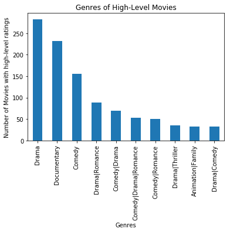

```python
hl_genre.plot.bar()
plt.xlabel('Genres')
plt.ylabel('Number of Movies with high-level ratings')
plt.title('Genres of High-Level Movies')
```

```python
# Output the Top 10 genre with best ratings within the cross-genre subgroup
high_level[high_level['genres_mixtype']=='cross-genre'].groupby('genres').mean().sort_values(by='vote_average').tail(10).vote_average
```

```
genres
Science Fiction|Adventure|Family                 8.0
Drama|Science Fiction|Comedy                     8.0
History|Drama|Thriller|War                       8.0
Adventure|Drama|Science Fiction                  8.0
Drama|Music|Comedy                               8.1
Drama|Action|Crime|Thriller                      8.1
Crime|Action                                     8.1
Thriller|Documentary                             8.2
Music|Drama|Fantasy|Romance                      8.4
Drama|Horror|Mystery|Science Fiction|Thriller    8.8
Name: vote_average, dtype: float64
```

```python
# Output the Top 10 genre with best ratings within the single-genre subgroup
high_level[high_level['genres_mixtype']=='single-genre'].groupby('genres').mean().sort_values(by='vote_average').tail(10).vote_average
```

```
genres
Comedy             6.635897
Romance            6.700000
Drama              6.737456
Western            6.800000
Science Fiction    6.850000
TV Movie           6.900000
War                6.900000
Animation          6.978571
Documentary        7.068103
Music              7.446154
Name: vote_average, dtype: float64
```

### To Q1b: Which year do the movies get the highest rating on average? Do the numbers differ by movies with cross-genre and single genre?

I use the group by function to create vote average numbers for each year. After that, I look closer to single-genre and cross-genre separately, if the numbers differ by release year. For the visualization, I create a line chart to compare both groups of movies for each year.

```python
high_level.groupby('release_year').mean() # groupby to get the average vote number for each year
```

| release_year | id | popularity | budget | revenue | runtime | vote_count | vote_average | budget_adj | revenue_adj |
| --- | --- | --- | --- | --- | --- | --- | --- | --- | --- |
| 2006 | 15004.700935 | 0.722453 | 1.992916e+07 | 5.329770e+07 | 104.911215 | 274.542056 | 6.602804 | 2.155676e+07 | 5.765048e+07 |
| 2007 | 17190.965665 | 0.701481 | 1.917690e+07 | 5.724916e+07 | 102.995708 | 292.004292 | 6.633047 | 2.016774e+07 | 6.020715e+07 |
| 2008 | 17785.568182 | 0.677254 | 1.793925e+07 | 5.021493e+07 | 103.871212 | 294.753788 | 6.619318 | 1.816863e+07 | 5.085701e+07 |
| 2009 | 34874.031621 | 0.742358 | 1.914009e+07 | 6.067626e+07 | 100.620553 | 343.719368 | 6.615810 | 1.945399e+07 | 6.167138e+07 |
| 2010 | 48031.656489 | 0.770821 | 2.269900e+07 | 5.802111e+07 | 100.362595 | 384.545802 | 6.700382 | 2.269900e+07 | 5.802111e+07 |
| 2011 | 68896.174377 | 0.772084 | 1.794386e+07 | 5.857354e+07 | 101.291815 | 363.313167 | 6.708897 | 1.739475e+07 | 5.678108e+07 |
| 2012 | 101194.522901 | 0.806563 | 1.979326e+07 | 7.593310e+07 | 100.587786 | 556.755725 | 6.648473 | 1.879853e+07 | 7.211703e+07 |
| 2013 | 166705.632911 | 0.821182 | 1.989728e+07 | 6.294066e+07 | 99.468354 | 516.202532 | 6.728165 | 1.862452e+07 | 5.891455e+07 |
| 2014 | 237385.221591 | 1.231804 | 1.556980e+07 | 5.589914e+07 | 100.446023 | 464.863636 | 6.765341 | 1.434120e+07 | 5.148820e+07 |
| 2015 | 292836.391304 | 1.449045 | 1.758177e+07 | 7.452721e+07 | 100.361204 | 469.354515 | 6.803679 | 1.617522e+07 | 6.856500e+07 |

```python
cross_genre_year = high_level[high_level['genres_mixtype']=='cross-genre'].groupby('release_year').mean().vote_average
```

```python
single_genre_year = high_level[high_level['genres_mixtype']=='single-genre'].groupby('release_year').mean().vote_average
```

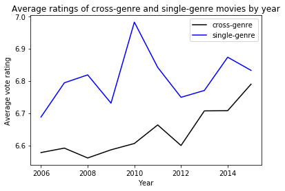

```python
plt.plot(cross_genre_year,'k',single_genre_year,'b')
plt.xlabel('Year')
plt.ylabel('Average vote rating')
plt.title('Average ratings of cross-genre and single-genre movies by year')
plt.legend({'cross-genre','single-genre'})
```

## Research Question 2 Production Type vs. Vote Average

a. What ratings do the movies of production companies get on average? What does the distribution look like?

b. Which production type (coproduction or non-copro) associated with higher ratings?

### To Q2a: What ratings do the movies of each production companies and coproductions get on average? What does the distribution look like?

To visualize the distribution of the ratings regarding production companies I use the histogram.

```
Text(0.5,1,'Distribution of production companies ratings')
```

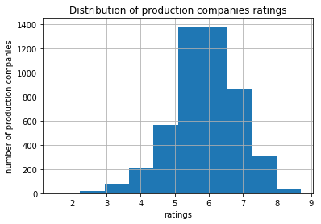

```python
df_p['vote_average'].hist() # plot the
plt.xlabel('ratings')
plt.ylabel('number of production companies')
plt.title('Distribution of production companies ratings')
```

### To Q2b: Which production type (coproduction or non-copro) associated with higher ratings?

Same as in Question 1, I divide the production companies into high-level and low-level. To set the level I use the median of average vote.

```python
median_pc_ratings = df_p.median().vote_average # get the median amount of vote average for the production companies - we use the genre_mixtype file
```

```python
median_pc_ratings
```

```
5.9000000000000004
```

```python
# select samples with average vote less than the median as low level
pc_low_level = df_p[df_p['vote_average']< 5.9]

# select samples with  average vote greater than or equal to the median as high level
pc_high_level = df_p[df_p['vote_average'] >= 5.9]

# ensure these queries included each sample exactly once
pc_num_samples = df_p.shape[0]
pc_num_samples == pc_low_level['budget'].count() + pc_high_level['budget'].count() # should be True
```

```
True
```

```python
df_p.groupby('production_type').mean().vote_average
```

```
production_type
coproduction         5.911795
single-production    5.842303
Name: vote_average, dtype: float64
```

```python
# Output of the Top 3 coproduction combination with best ratings within the coproduction subgroup
pc_high_level[pc_high_level['production_type']=='coproduction'].groupby('production_companies').mean().sort_values(by='vote_average').tail(3).vote_average
```

```
production_companies
Blumhouse Productions|Hit the Ground Running Films    8.4
Red Bull Media House|Brain Farm Digital Cinema        8.5
SMV Enterprises|Columbia Music Video|EMI              8.7
Name: vote_average, dtype: float64
```

```python
# Output of the Top 3 production company with best ratings within the single production subgroup
pc_high_level[pc_high_level['production_type']=='single'].groupby('production_companies').mean().sort_values(by='vote_average').tail(3).vote_average
```

[output not shown]

```
Series([], Name: vote_average, dtype: float64)
```

## Conclusions

### Q1b:

On average, movies released in 2015 got higher ratings than the years before. In the period from 2006-2015, single-genre movies were rated higher than the cross-genre movies for each year.

### Q2a:

From 2006 to 2015, most of the production companies (including all of the combinations within the production companies) are rated in the range from 5 to 6.5 on average, the distribution is slightly left-skewed, the median is greater than the mean.

## Submitting your Project

> Before you submit your project, you need to create a .html or .pdf version of this notebook in the workspace here. To do that, run the code cell below. If it worked correctly, you should get a return code of 0, and you should see the generated .html file in the workspace directory (click on the orange Jupyter icon in the upper left).

> Alternatively, you can download this report as .html via the **File** > **Download as** submenu, and then manually upload it into the workspace directory by clicking on the orange Jupyter icon in the upper left, then using the Upload button.

> Once you've done this, you can submit your project by clicking on the "Submit Project" button in the lower right here. This will create and submit a zip file with this .ipynb doc and the .html or .pdf version you created. Congratulations!

```python
from subprocess import call
call(['python', '-m', 'nbconvert', 'Investigate_a_Dataset.ipynb'])
```

```
0
```